# EDA with Dplyr and Ggplot

Cube Statistica

2022-09-20

The tutorial will show you how to use data cleaning, transformation and visualization to explore the data in the systematic manner. This is a task Statisticians refer as **Exploratory Data Analysis (EDA)**.

Specifically, EDA is an iterative cycle :

1. Generate questions about the data.
2. Search for answers by visualizing, transforming and modelling your data.
3. Use what you learn to refine your questions and/or generate new questions.

Data Cleaning is just one application of EDA: A process of transforming raw data into consistent data that can be analyzed.

Some of the examples of data cleaning is that the data is consistent, have correct data types and missing data is imputed. We will start with loading the tidyverse package and our data set.

## Importing Packages

```r
library(tidyverse)
library(lubridate)
```

```r
dataRaw <- read_csv("Data-DS-C1-Course.csv")
head(dataRaw, n = 10)
```

```
## # A tibble: 10 x 29
##    Timestamp  `Student ID` `Do you unders~` `Course Fee Em~` `Date sent` Payment
##    <chr>             <dbl> <chr>            <chr>            <date>      <chr>
##  1 8/25/2022~            1 Yes              Sent             2022-08-26  Paid
##  2 8/22/2022~            2 No               Sent             2022-08-23  Pending
##  3 8/22/2022~            3 No               Sent             2022-08-23  Pending
##  4 8/22/2022~            4 No               Sent             2022-08-23  Pending
##  5 8/22/2022~            5 Yes              Sent             2022-08-23  Maybe
##  6 8/22/2022~            6 No               Sent             2022-08-23  Pending
##  7 8/22/2022~            7 No               Sent             2022-08-23  Pending
##  8 8/22/2022~            8 Yes              Sent             2022-08-23  Pending
##  9 8/22/2022~            9 No               Sent             2022-08-24  Pending
## 10 8/22/2022~           10 No               Sent             2022-08-24  Pending
## # ... with 23 more variables: `Payment Receipt Sent` <chr>,
## #   `How and where did you hear about this course?` <chr>,
## #   `Which Country are you currently residing in?` <chr>,
## #   `Which City are you currently residing in?` <chr>, Gender <chr>, Age <chr>,
## #   `Are you currently attending University / College?` <chr>,
## #   `Latest Degree Completed or in Progress?` <chr>,
## #   `Name of University or College currently or previously attended?` <chr>, ...
```

EDA is fundamentally a creative process. Like any creative processes, the key is to ask quality questions. In our course data set, we will ask the following questions:

1. How has number of responses in form varied over the time?
2. What is the distribution of university the students filled out the form?
3. Which social platform students heard about the course?

While we will restrict our tutorial to these questions but you can think of other questions when making your dashboard:

1. What is Distribution of country and city the responses are from ?
2. How does paying for the course correlate with Gender and Age ?
3. What Prior Work experience in R and Python the students have ?

## Data Cleaning

For our set of specified questions, we start by selecting the variables of interest. Specifically, we will select the following variables:

1. Student ID
2. Time stamp
3. Name of University or College currently or previously attended ?

Before data selection, we will rename the columns as some columns have spaces and have long names. We will use rename function in dplyr package.

```r
dataRenamed <- dataRaw %>%
  rename("Id" = "Student ID",
         "Date_time" = "Timestamp",
         "Qr_uni_col" = "Name of University or College currently or previously attended?"
         )

# Check for renaming
names(dataRenamed[1:10])
```

```
##  [1] "Date_time"
##  [2] "Id"
##  [3] "Do you understand that this is a paid course ?...3"
##  [4] "Course Fee Email"
##  [5] "Date sent"
##  [6] "Payment"
##  [7] "Payment Receipt Sent"
##  [8] "How and where did you hear about this course?"
##  [9] "Which Country are you currently residing in?"
## [10] "Which City are you currently residing in?"
```

Now we will select the required variables.

```r
# select variables for analysis
dataSelected <- select(dataRenamed,
                       Id, Date_time, Qr_uni_col)

# make ID rowname of data frame
dataSelected <- column_to_rownames(dataSelected , var = "Id")

head(dataSelected)
```

```
##            Date_time                                            Qr_uni_col
## 1 8/25/2022 14:35:19                                University of Illinois
## 2  8/22/2022 5:25:04                                        Ned university
## 3  8/22/2022 5:26:34                  Univeristy of agriculture, Faislabad
## 4  8/22/2022 5:27:38 Institute of Management Sciences Peshawar (IMScieces)
## 5  8/22/2022 5:31:42                  Institute of Business Administration
## 6  8/22/2022 5:32:14                  Institute of Business Administration
```

### How has number of responses in form varied over the time?

Let us say we want to analyze how number of responses have varied over time. For this we start by correcting the date-time variable type with help of lubridate

```r
# Convert time column to data-time type
dataSelected$Date_time <- lubridate::mdy_hms(dataSelected$Date_time)

# Make date and time in separate variables
dataSelected <- tidyr::separate(dataSelected, Date_time, c("Date", "Time"), sep = " ")

# Convert Date to date type
dataSelected$Date <- lubridate::ymd(dataSelected$Date)

head(dataSelected)
```

```
##         Date     Time                                            Qr_uni_col
## 1 2022-08-25 14:35:19                                University of Illinois
## 2 2022-08-22 05:25:04                                        Ned university
## 3 2022-08-22 05:26:34                  Univeristy of agriculture, Faislabad
## 4 2022-08-22 05:27:38 Institute of Management Sciences Peshawar (IMScieces)
## 5 2022-08-22 05:31:42                  Institute of Business Administration
## 6 2022-08-22 05:32:14                  Institute of Business Administration
```

After separating date and time variables, we can create grouped summaries to see students filling out the form

```r
# make grouped summary of students by day
groupedDate <- dataSelected %>%
  group_by(day = lubridate::floor_date(x = Date, unit = 'day')) %>%
  summarize(grouped = n())

groupedDate
```

```
## # A tibble: 14 x 2
##    day        grouped
##    <date>       <int>
##  1 2022-08-20       1
##  2 2022-08-22     109
##  3 2022-08-23      24
##  4 2022-08-24      20
##  5 2022-08-25      42
##  6 2022-08-26       9
##  7 2022-08-27       5
##  8 2022-08-28      18
##  9 2022-08-29       5
## 10 2022-08-31       6
## 11 2022-09-01       4
## 12 2022-09-03       2
## 13 2022-09-04       1
## 14 2022-09-07       1
```

Now we can make a time series plot to see the trend of course participation.

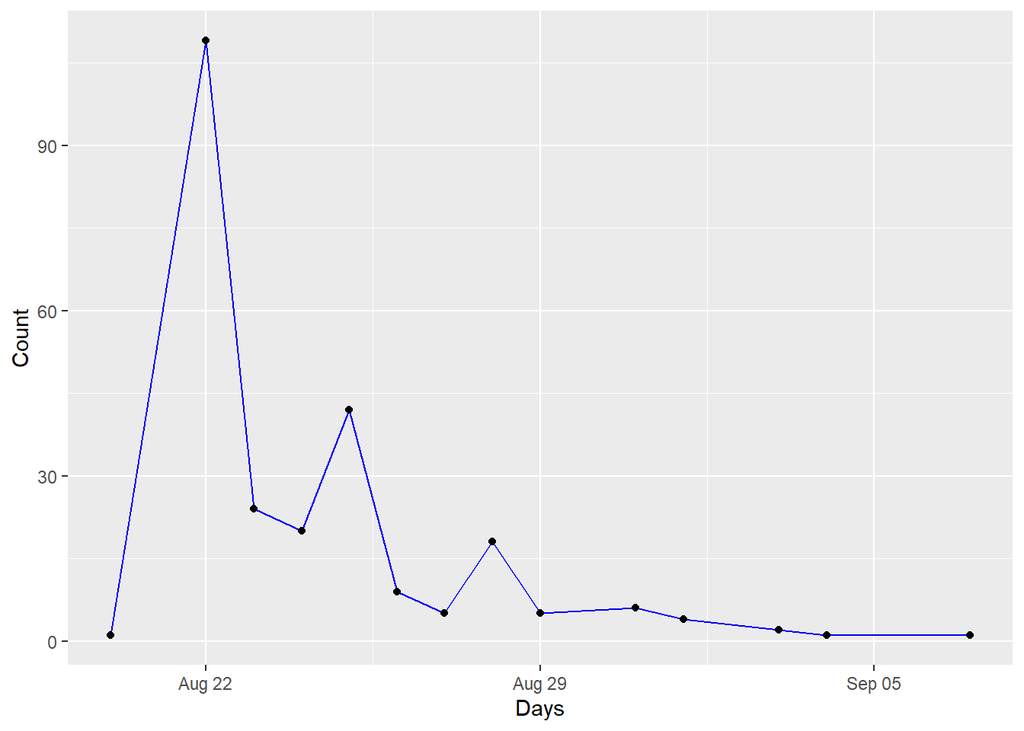

```r
ggplot(data = groupedDate, mapping = aes(x = day, y = grouped)) +
  geom_line(color = "blue") +
  geom_point() +
  xlab("Days") +
  ylab("Count") +
  scale_x_date(limit=c(as.Date("2022-08-20"),as.Date("2022-09-07")))
```

### What is the distribution of university ?

Another important aspect of registrations to see which University and discipline the students are from. We start by cleaning the university variable

```r
dataSelected %>%
  select(Qr_uni_col) %>%
  distinct() %>% #this line removes duplicates
  count()
```

```
##     n
## 1 143
```

```r
# First six unique values
head(unique(x = dataSelected$Qr_uni_col))
```

```
## [1] "University of Illinois"
## [2] "Ned university"
## [3] "Univeristy of agriculture, Faislabad"
## [4] "Institute of Management Sciences Peshawar (IMScieces)"
## [5] "Institute of Business Administration"
## [6] "Institute of Management Sciences Peshawar"
```

There are 143 unique values currently for University background. If you see the list, there are duplicates in the entries. There are some clear categories that we can combine jobs into. For example, “Iba Karachi”, “IBA” and “Institute of Business Administration” can be combined into “IBA”. We will use three functions to do this

- mutate() to change or create new variables
- case_when() as a kind of if/else command
- str_detect() to select specified text

```r
dataCategorized <- dataSelected %>%
  mutate(
    Uni_col = case_when(
      str_detect(
        Qr_uni_col,
        "IBA|Institute of Business Administration|Iba Karachi|IBA, Karachi|Iba Karachi|institute of business administration|Institute of business administration|INSTITUTE OF BUSINESS ADMINISTRATION KARACHI|Institute Of Business Administration|Institute Of Business Administration, Karachi|Institute of Business Adminstration|Institute of business administration karachi|INSTITUTE OF BUISNESS ADMINISTRATION KARACHI"
      ) ~ "IBA",
      str_detect(
        Qr_uni_col,
        "Azam|Quaid I azam university|Quaid-I-Azam University, Islamabad|Quaid e Azam University|Quaid e Azam university       Islamabad|Quaid-e-Azam University Islamabad|Quaid-i-Azam University Islamabad|Quaid e Azzam university Islamabad"
      ) ~ "QU",
      str_detect(
        Qr_uni_col,
        "Sir syed university of Engineering Technology|Sir syed university of engineering and technology|Sir Syed University|Sir Syed University Of Engineering And Technology|Sir Syed University Of Engineering & Technology|Sir syed University of engineering and technology|Sirsyed university of engineering and technology|Sir Syed University of Engineering and Technology|Sir Syed university of engineering and technology|Sur Syed University of Engineering and Technology|Sir Syed University Engineering Technology"
      ) ~ "SYED",
      str_detect(
        Qr_uni_col,
        "Ned university|NED University of Engineering and Technology Karachi|NED|Ned University"
      ) ~ "NED",
      str_detect(Qr_uni_col, "IQRA|Iqra|iqra|iqra university") ~ "IQRA",
      str_detect(Qr_uni_col, "Sindh") ~ "SMIU" ,
      str_detect(Qr_uni_col, "Karachi|University of karachi") ~ "KU",
      str_detect(Qr_uni_col, "Szabist", ) ~ "SZABIST",
      str_detect(Qr_uni_col, "Management|management", ) ~ "IOBM",
      str_detect(Qr_uni_col, "University of engineering and technology Peshawar") ~ "UET",
      TRUE ~ Qr_uni_col  #keep all others same
    )
  )
```

Let us check how many distinct entries we have.

```r
dataCategorized %>%
  select(Uni_col) %>%
  distinct() %>% #this line removes duplicates
  count()
```

```
##    n
## 1 71
```

```r
# see the unique values
head(unique(x = dataCategorized$Uni_col))
```

```
## [1] "University of Illinois"
## [2] "NED"
## [3] "Univeristy of agriculture, Faislabad"
## [4] "IOBM"
## [5] "IBA"
## [6] "SMIU"
```

We have reduced from 143 unique values to 71 values only. This means we have made our data more consistent. Now we make Bar Plot to visualize it.

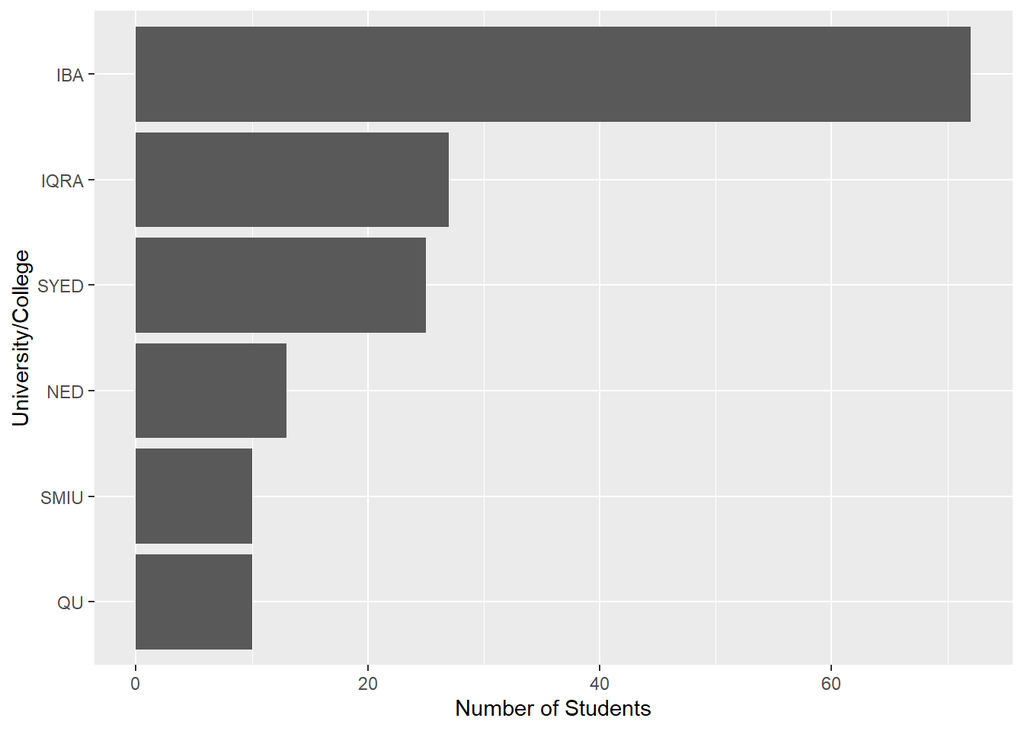

```r
# Sort universities by their frequencies
uniSorted <- dataCategorized %>%
  group_by(Uni_col) %>%
  summarise(Total = n()) %>%
  arrange(desc(Total)) %>%
  head(n = 6)

# Make Bar Plot
p <- ggplot(data = uniSorted, aes(x= reorder(Uni_col, Total), y = Total)) +
  geom_bar(stat="identity") +
  coord_flip() +
  ylab("Number of Students") +
  xlab("University/College")

p
```

We see that 29.1% of the students participated were from IBA followed by IQRA and Sir Syed University 10.9% and 10.1 % respectively.